# Week 4: Messaging and Wording

Lecture

Mohammed Ali Sharafuddin

## Week 4 Lecture: Messaging and Wording

Discussion

**1 Introduction**

⏱ 10 min

Week overview, copy-as-decision brief, Week 2 canvas plus Week 3 visual asset handover

Acquisition

**2 Theory and Application**

⏱ 30 min

TPB, ELM/HSM, anchoring, priming, framing, Cialdini’s principles, copy structure, tone/readability, message testing

Practice

**3 Guided Worked Example**

⏱ 15 min

Applying the evidence framework to the Villa College Certificate copybook

Assessment

**4 Attendance and Exit Check**

⏱ 5 min

Attendance, Moodle concept check

## Module Arc

**Weeks 1–2**

Foundations and Planning

→

**Weeks 3–5**

Content and Media

→

**Weeks 6–8**

Acquisition Channels

→

**Weeks 9–12**

Relationships and Measurement

→

**Weeks 13–15**

Governance and AI

> **We remain in Weeks 3 to 5: Content and Media.** Week 3 gave the campaign its visual argument. This week gives it a verbal argument. Every copy decision must trace back to the same canvas, the same hierarchy stage, and the same processing route that governed Week 3.

## Today’s Agenda

**Lecture: eleven theory and practice sections**

1. Why copy is itself a campaign decision
2. The theory of planned behaviour: diagnosing the weakest link
3. ELM and HSM: central/systematic versus peripheral/heuristic
4. Anchoring and priming: cognitive shortcuts that operate below awareness
5. Framing theory: gain frames versus loss frames
6. Cialdini’s six principles: the persuasion mechanism map
7. Copy structure: hook, claim, evidence, call to action
8. Tone, readability, and accessibility
9. Headlines and the first three seconds
10. Message testing: designing a minimum-viable A/B test
11. AI copy generation: uses, limits, and evidence standards

**Tutorial preview**

You will build a real ad mockup in Canva:

- Diagnose your audience’s TPB weak link and write a four-line copy brief
- Build the hook, claim, evidence, and call to action in Canva (40-minute sprint)
- Scroll-test a partner’s phone, then answer three critique questions
- Fix, write the message test plan, and check readability and contrast
- Vote live on Hook A versus Hook B, then complete the copy decision record

## Learning Objectives (1 of 2)

After studying this chapter, you should be able to:

1. Apply the **theory of planned behaviour** to identify the weakest link, attitude, subjective norm, or perceived behavioural control, in an audience’s path from belief to action.
2. Distinguish the **ELM’s** central and peripheral routes from the **heuristic-systematic model’s** systematic and heuristic processing.
3. Identify **anchoring and priming** effects in a campaign context and apply each deliberately.
4. Apply **framing theory** to write the same core claim in gain-frame and loss-frame versions.
5. Use **Cialdini’s six principles** to identify the persuasive mechanism most appropriate to the target segment and hierarchy stage.

## Learning Objectives (2 of 2)

After studying this chapter, you should be able to:

6. Construct a **four-part copy structure** (hook, claim, evidence, call to action) that passes a **tone, readability, and accessibility** check.
7. Write a **headline** matched to the visual hierarchy and the audience’s processing route.
8. Distinguish a **message test** from a creative preference test.
9. Evaluate **AI-generated copy** against the evidence standard.
10. Apply the **evidence framework**: classify message choices as evidence-based, inferred, or assumed.

> **Objective 10 applies the module’s evidence discipline to words.** An untraceable claim gets labelled as an assumption.

## Why Copy Is a Campaign Decision

> Digital marketing copy is a strategic decision. The exact words used to frame a claim change whether the audience perceives the offer as a gain or a loss, whether they trust the source, and whether they act or defer.

**A message written for the wrong audience state fails structurally, whatever its style.**

## The Theory of Planned Behaviour

> A person’s intention to act, and so the behaviour itself, is predicted by three independent factors: **attitude** toward the behaviour, the **subjective norm** they perceive around it, and their **perceived behavioural control** over performing it.

**Ajzen, 1991. A diagnostic tool: it identifies which factor is weakest, so copy can target that link specifically.**

## TPB: Diagnosing the Weak Link

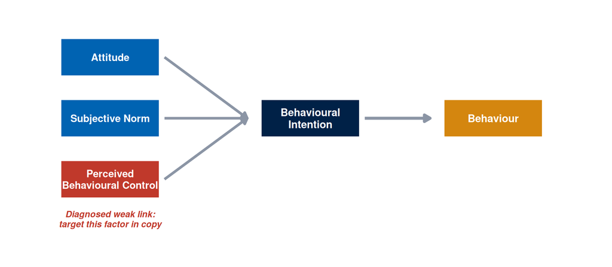

## Processing Routes: ELM and HSM

> Your Week 2 canvas already records an ELM processing route: central for an audience that evaluates arguments, peripheral for an audience that responds to cues. The **heuristic-systematic model**, developed independently by Chaiken, describes the same split with a different emphasis.

**ELM tells you whether to write for argument or for cue. HSM tells you which specific heuristic to supply.**

## Anchoring and Priming

> **Anchoring** is the tendency to rely too heavily on the first number encountered when making a subsequent judgement. **Priming** is the tendency for exposure to one stimulus to shape how a person interprets a subsequent, unrelated stimulus.

**Both effects were documented in the same research programme that produced prospect theory (Tversky and Kahneman, 1974), and both operate below conscious evaluation.**

## Anchoring and Priming: The Diagrams

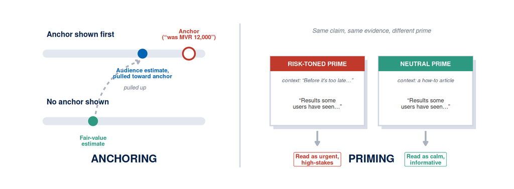

## Anchoring in Real Campaigns

[figure not shown]

## Priming in Real Campaigns

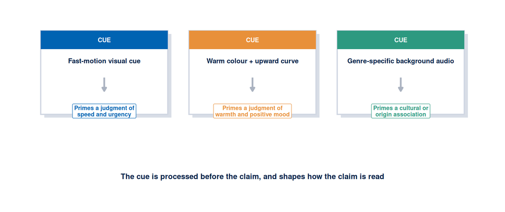

## Live: Anchoring on a Real Hotel Map

[interactive chart not shown]

**Point out live:** the price pin on every marker (an anchor before a single word is read), the “great deal, X% less than usual” badge (an anchor against the site’s own usual price), and the sponsored listing at the top of the list (an authority/priority cue, not a price signal).

## Framing Theory

> The same information can produce different responses depending on how it is presented. Information presented as a potential **loss** generates stronger motivation to act than the same information presented as a potential **gain**.

**Kahneman and Tversky, prospect theory (1979). Entman, framing theory (1993).**

## Gain Frame vs Loss Frame

[interactive chart not shown]

## A Textbook Framing Example

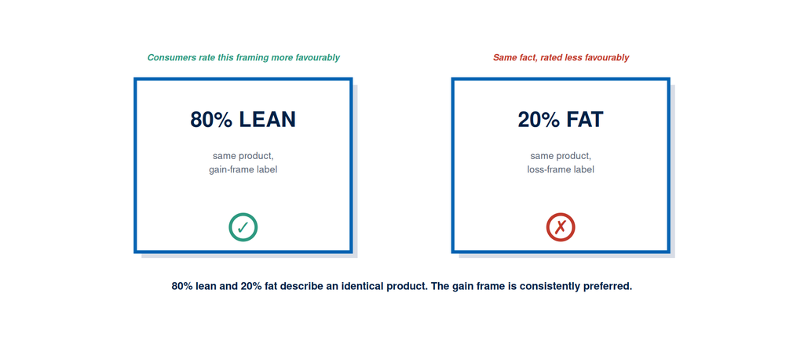

**Vote: which label would make you pick up the pack?** Both describe the identical product.

## Cialdini’s Six Principles of Influence

> Six principles describe the psychological mechanisms through which persuasion operates: reciprocity, commitment and consistency, social proof, authority, liking, and scarcity.

**Cialdini, 2007. A diagnostic: deploy the one or two principles that fit the stage.**

## Applicability Across the Hierarchy

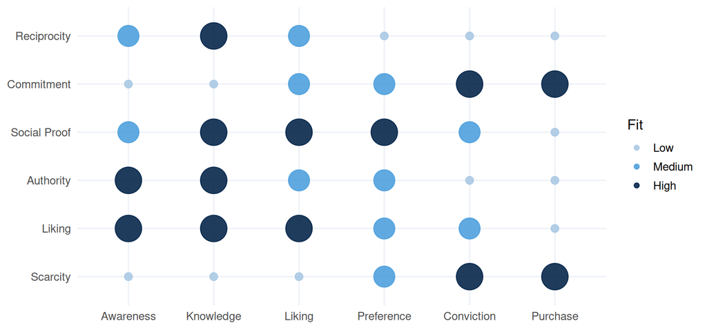

## Cialdini’s Six Principles: Reference Wheel

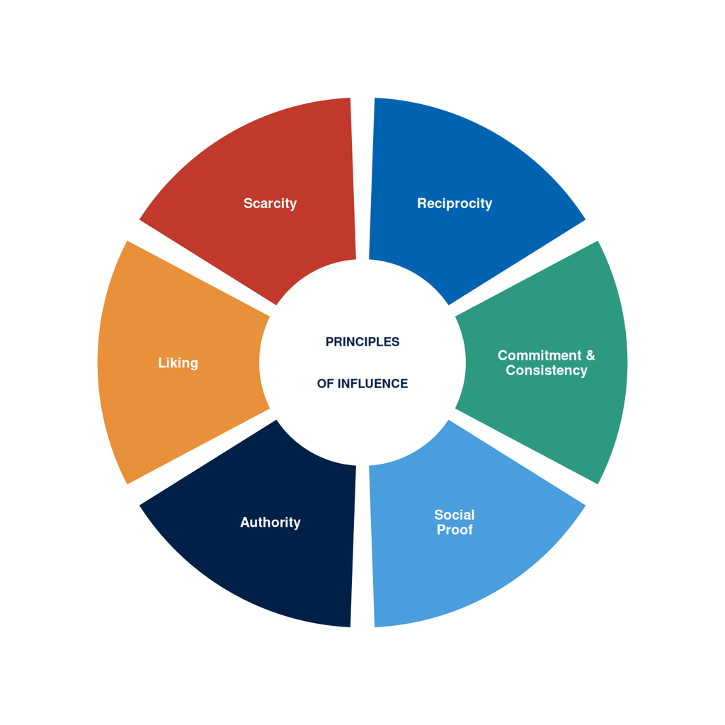

## Copy Structure: Hook, Claim, Evidence, Call to Action

> Every effective campaign message has four functional parts. A message with three of the four fails at a specific, predictable point.

**The four-part structure is a decision sequence: write each part on purpose, in order.**

## The Four Parts

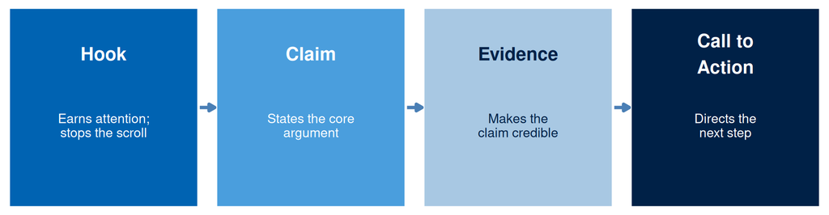

| Part | Central-route version | Peripheral-route version |
| --- | --- | --- |
| **Hook** | Surfaces a specific, articulated problem | Creates a visual or social cue |
| **Evidence** | Named statistic, testimonial, accreditation | Partner logo, award badge, user count |
| **Call to action** | “See the programme structure” (Knowledge) | “Find out more” (Awareness) |

## Tone, Readability, and Accessibility

> The four-part structure governs what a message says. Tone, readability, and accessibility govern whether the audience can receive it at all.

**A message with all four parts still fails if the sentence is too dense to parse in the three seconds a scrolling audience gives it.**

## Before and After a Readability Pass

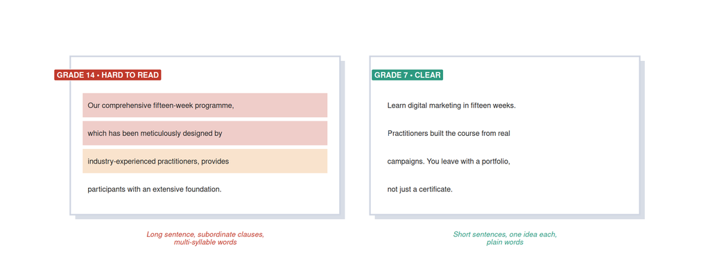

**Free tools, no sign-up:** Hemingway Editor (hemingwayapp.com) for reading grade level; WebAIM Contrast Checker for the call-to-action colour pair.

## Headlines and the First Three Seconds

> The audience’s decision to continue or stop is made in the first few seconds of exposure, driven by whether the opening line answers: **“Is this for someone like me, in my situation, with my concern?”**

**A headline performs three functions simultaneously: identifies the audience, names the problem, promises a resolution.**

## What Makes a Headline Work

| Function | Example |
| --- | --- |
| **Identifies the audience** | “For marketing officers in Maldivian hospitality…” |
| **Names the problem or desire** | “…who need a credential that travels…” |
| **Promises a resolution** | “…a fifteen-week programme that produces a portfolio you can show at any interview.” |

**Context adaptation:** a Google Search headline answers a query the audience already typed. A Facebook Feed headline must create the need before it can address one. A headline optimised for one context tends to underperform in the other.

## Message Testing

> A message test measures audience response to two or more versions of a message. It settles the question with data, not with a team vote on preference.

**A hypothesis paired with a decision rule is an experiment; a hypothesis alone is an interest.**

## Five Components of a Minimum-Viable Test

1. **One variable changed.** Test the hook only, or the call to action only, or the frame only.
2. **A stated hypothesis.** “Variant A will produce a higher click-through rate because [rationale linked to TPB, framing, or hierarchy stage].”
3. **An outcome metric matched to the hierarchy stage.** Awareness: reach. Knowledge: click-through. Preference: engagement with comparison content. Conviction: conversion rate.
4. **A minimum sample size.** 300 to 500 impressions per variant is typical for a campaign this size.
5. **A decision rule, fixed before the result is known.** “If Version A achieves a higher click-through rate at 95 per cent confidence, we adopt Version A.”

## AI Copy Generation: Uses, Limits, Evidence Standards

| **Permitted and useful** | **Restricted** |
| --- | --- |
| Generate structural variants (same claim, different framings) | Generate audience facts that lack documentation |
| Draft opening lines for review and selection | Generate testimonials or social proof never collected from real customers |
| Check whether a message stays internally consistent with the brief | Insert specific claims that lack verification from a cited source |
| Generate a list of audience objections to test against | Submit AI copy without human review against the evidence standard |

> **Every AI-generated copy element used in any submission must appear in the prompt log**, with the exact prompt, the output, and the student’s decision about what was accepted, rejected, or revised.

## Worked Example: Villa College Certificate

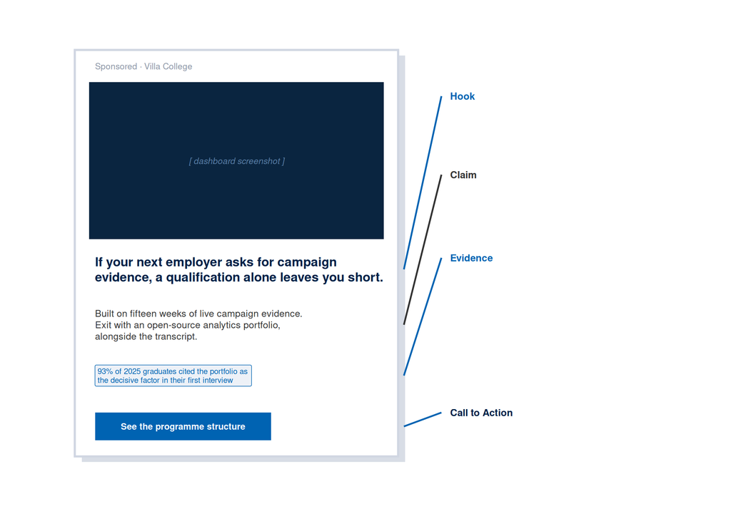

## Vote: Which One Stops You?

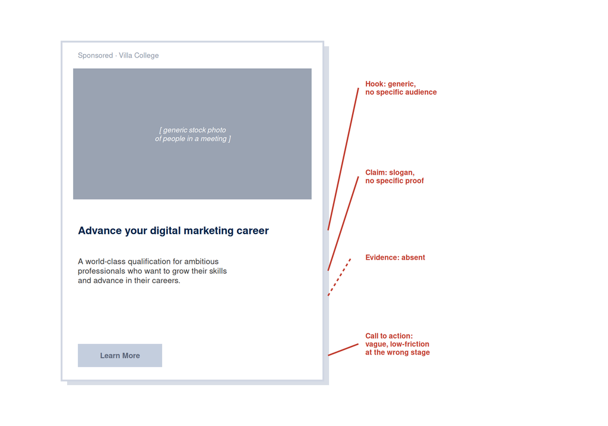

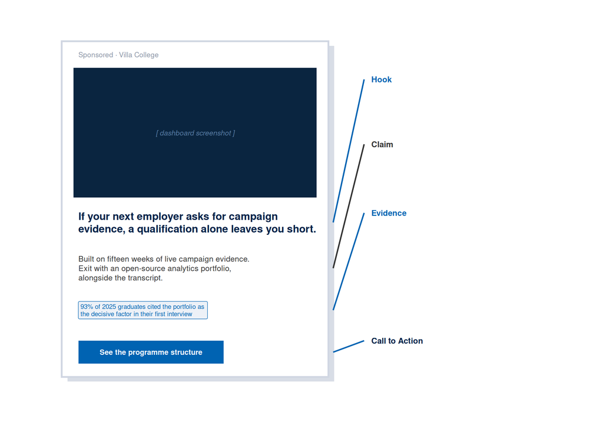

**Hands up: which one would make you stop scrolling? Why?**

## Two More Worked Examples

The same decision sequence applies to any campaign category. Two condensed examples from this week’s chapter:

[output not shown]

> Whichever category your own campaign is closest to, hold your draft next to the matching worked example in the chapter before the tutorial’s build sprint.

## Applying the Evidence Framework to Copy

> A claim derived from documented audience research is evidence-based. A claim derived from a reasonable interpretation of that evidence is an inference. A claim representing an untested belief about the audience is an assumption.

**“Our audience values flexibility above all else” is an assumption unless traceable to a documented source.**

## Exit Ticket

### Complete the Week 4 Quiz in Moodle before moving to the tutorial.

12 questions, unlimited attempts, 70 per cent to unlock the assignment.